# Multivariate Time-Series Models: a case study to analyze macro-economic time series

Time Series Analysis and Forecasting, Master in Big Data Analytics

Javier Nogales

UC3M, 2024

# Introduction

We are going to analyze the dynamic relation between some macro-economic variables from the US: personal income, personal consumption expenditures, industrial production, personal savings rate, unemployment people

```r
library(tidyverse) # great collection of packages to visualize and manage datasets
library(lubridate) # to work with dates
library(fpp3)
```

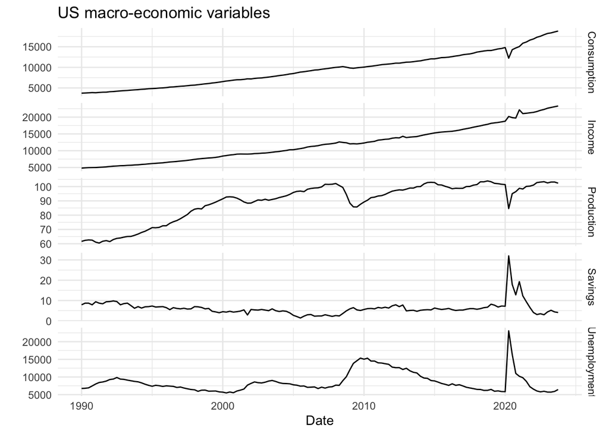

```r
library(eFRED) # variables from FRED

# US personal income (quarterly), Personal Consumption Expenditures, Industrial Production, Personal savings rate, Unemployment people (in thousands)

# Download all the variables and compute quarterly percentage differences

data.fred = fred(c("PINCOME", "PCE", "INDPRO", "PSAVERT", "UNEMPLOY"))
data.fred = data.fred %>% filter(year(date)>=1990) %>% drop_na()
names(data.fred) = c('Date', 'Income', 'Consumption', 'Production', 'Savings', 'Unemployment')

# Original variables
data.fred %>%
  pivot_longer(c(2:6), names_to = "var", values_to = "value") %>%
  ggplot(aes(x = Date, y = value)) +
  geom_line() +
  facet_grid(vars(var), scales = "free_y") + theme_minimal()+
  labs(title = "US macro-economic variables",
       y = "")
```

Insights? How are variables affecting each other?

We should make the variables stationary:

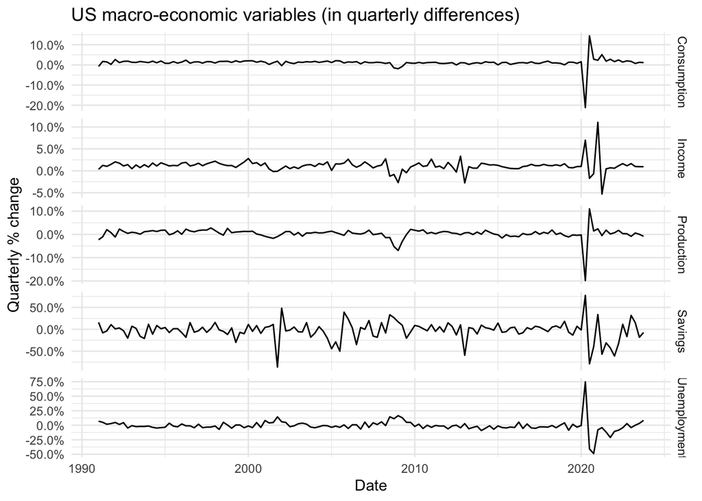

```r
data.fred = data.fred %>% mutate(across(where(is.numeric),  ~  (.x-lag(.x))/.x)) %>% filter(year(Date)>=1991)

#save(data.fred, file="macrovariables.RData")
#load("macrovariables.RData")

data.fred %>%
  pivot_longer(c(2:6), names_to = "var", values_to = "value") %>%
  ggplot(aes(x = Date, y = value)) +
  geom_line() + scale_y_continuous(labels = scales::percent_format(accuracy = .1))+
  facet_grid(vars(var), scales = "free_y") + theme_minimal()+
  labs(title = "US macro-economic variables (in quarterly differences)",
       y = "Quarterly % change")
```

# Outliers

```
## Series: ts_data
## Regression with ARIMA(1,0,0) errors
##
## Coefficients:
##          ar1  intercept     AO89   AO118    TC119   AO121
##       0.2691     0.0114  -0.0439  0.0564  -0.0378  0.1283
## s.e.  0.0920     0.0010   0.0082  0.0083   0.0077  0.0088
##
## sigma^2 = 7.296e-05:  log likelihood = 444.43
## AIC=-874.85   AICc=-873.95   BIC=-854.67
##
## Outliers:
##   type ind    time  coefhat  tstat
## 1   AO  89 2013:01 -0.04386 -5.346
## 2   AO 118 2020:02  0.05642  6.775
## 3   TC 119 2020:03 -0.03778 -4.919
## 4   AO 121 2021:01  0.12835 14.631
```

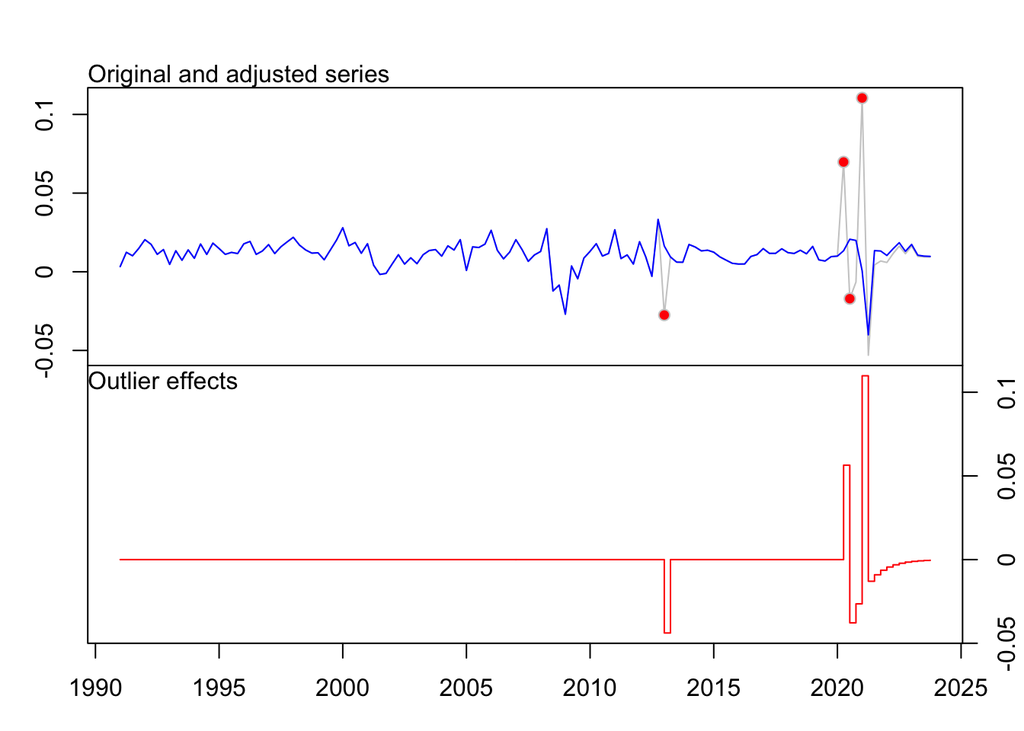

```
## Series: ts_data
## Regression with ARIMA(0,0,2) errors
##
## Coefficients:
##           ma1     ma2  intercept     LS64     AO73    AO118   TC119    LS121
##       -0.7517  0.4772     0.0139  -0.0046  -0.0487  -0.1917  0.0816  -0.0151
## s.e.   0.0821  0.0954     0.0006   0.0009   0.0057   0.0060  0.0040   0.0038
##        LS123
##       0.0175
## s.e.  0.0039
##
## sigma^2 = 5.305e-05:  log likelihood = 466.68
## AIC=-913.36   AICc=-911.54   BIC=-884.53
##
## Outliers:
##   type ind    time   coefhat   tstat
## 1   LS  64 2006:04 -0.004608  -4.874
## 2   AO  73 2009:01 -0.048710  -8.546
## 3   AO 118 2020:02 -0.191667 -31.843
## 4   TC 119 2020:03  0.081565  20.169
## 5   LS 121 2021:01 -0.015147  -4.012
## 6   LS 123 2021:03  0.017536   4.503
```

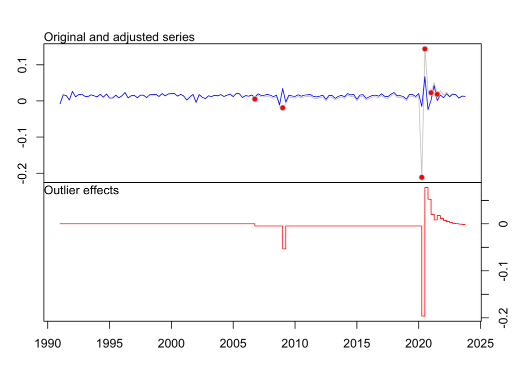

```
## Series: ts_data
## Regression with ARIMA(1,0,0) errors
##
## Coefficients:
##          ar1  intercept     TC72    AO118
##       0.3677     0.0065  -0.0554  -0.2354
## s.e.  0.0933     0.0019   0.0126   0.0138
##
## sigma^2 = 0.0001824:  log likelihood = 382.86
## AIC=-755.73   AICc=-755.25   BIC=-741.31
##
## Outliers:
##   type ind    time  coefhat   tstat
## 1   TC  72 2008:04 -0.05542  -4.403
## 2   AO 118 2020:02 -0.23540 -17.039
```

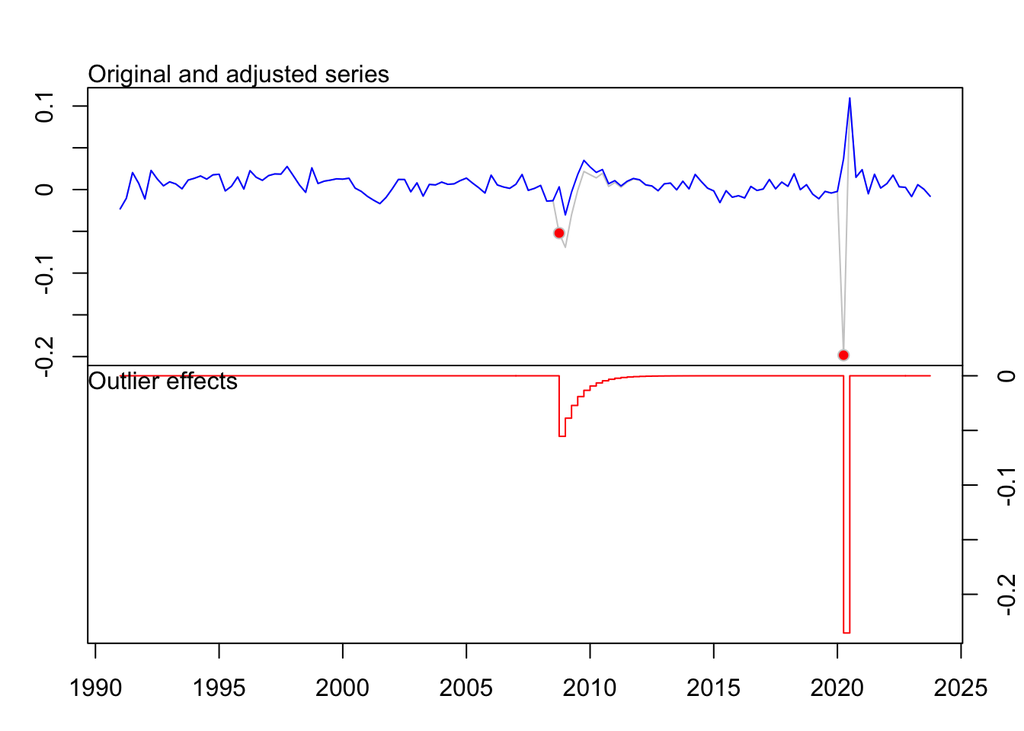

```
## Series: ts_data
## Regression with ARIMA(0,0,0) errors
##
## Coefficients:
##          AO44     AO89   AO118
##       -0.8621  -0.5918  0.7750
## s.e.   0.1845   0.1845  0.1845
##
## sigma^2 = 0.03484:  log likelihood = 35.78
## AIC=-63.56   AICc=-63.25   BIC=-52.03
##
## Outliers:
##   type ind    time coefhat  tstat
## 1   AO  44 2001:04 -0.8621 -4.672
## 2   AO  89 2013:01 -0.5918 -3.208
## 3   AO 118 2020:02  0.7750  4.200
```

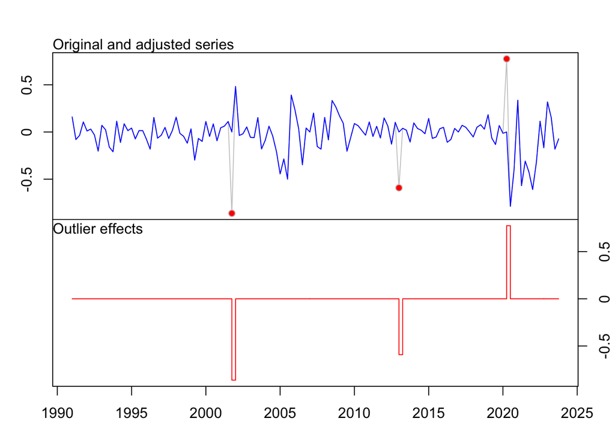

```
## Series: ts_data
## Regression with ARIMA(0,0,0) errors
##
## Coefficients:
##         TC71     LS79   AO118    TC119    AO120
##       0.1877  -0.0222  0.7692  -0.3319  -0.2339
## s.e.  0.0301   0.0061  0.0425   0.0364   0.0486
##
## sigma^2 = 0.00184:  log likelihood = 230.91
## AIC=-449.82   AICc=-449.15   BIC=-432.52
##
## Outliers:
##   type ind    time  coefhat  tstat
## 1   TC  71 2008:03  0.18773  6.246
## 2   LS  79 2010:03 -0.02221 -3.632
## 3   AO 118 2020:02  0.76920 18.091
## 4   TC 119 2020:03 -0.33192 -9.130
## 5   AO 120 2020:04 -0.23391 -4.812
```

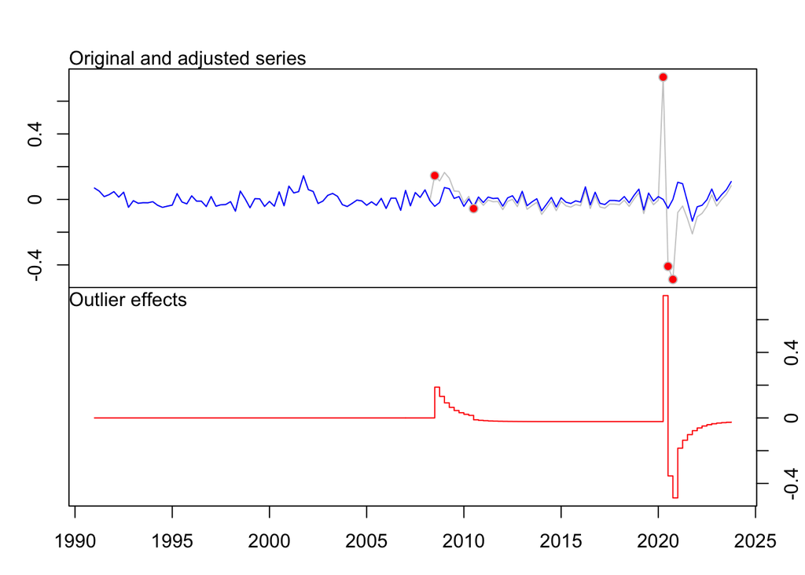

```r
library(tsoutliers)

# Identify outliers in an outmatic way
# Loop for each variable in data.fred
for (var in names(data.fred)[-1]) {
  ts_data <- ts(data.fred[[var]], start=c(1991,1), frequency=4)

  # Detect outliers
  outliers <- tso(ts_data)

  # Check the results
  print(outliers)
  plot(outliers)

  # Add the adjusted data back to the data frame
  data.fred[[paste0(var, ".adjusted")]] <- outliers$yadj
}
```

```r
# Check the updated data frame structure
names(data.fred)
```

```
##  [1] "Date"                  "Income"                "Consumption"
##  [4] "Production"            "Savings"               "Unemployment"
##  [7] "Income.adjusted"       "Consumption.adjusted"  "Production.adjusted"
## [10] "Savings.adjusted"      "Unemployment.adjusted"
```

Now we decide if we want to work with the original time series or the filtered one. One choice is to work with the filter one in the training set, and the original one in the testing one.

# VAR models

Let’s fit an automatic VAR model (using fable) based on bic to select the best model

```r
dataUS = data.fred %>% select(-Date) %>%
  ts(start=c(1991,1), frequency=4) %>% as_tsibble(pivot_longer = FALSE) %>% drop_na()

# leave 2022 and 2023 for testing
fit <-  dataUS %>% filter(year(index)<2022) %>%
  model(VAR1=VAR(vars(Income.adjusted, Consumption.adjusted, Savings.adjusted, Production.adjusted, Unemployment.adjusted) ~ 0+AR(1)),
        aicc=VAR(vars(Income.adjusted, Consumption.adjusted, Savings.adjusted, Production.adjusted, Unemployment.adjusted), ic="aicc" ),
        bic=VAR(vars(Income.adjusted, Consumption.adjusted, Savings.adjusted, Production.adjusted, Unemployment.adjusted), ic="bic")
  )

fit
```

```
## # A mable: 1 x 3
##       VAR1     aicc              bic
##    <model>  <model>          <model>
## 1 <VAR(1)> <VAR(4)> <VAR(0) w/ mean>
```

```r
glance(fit)
```

```
## # A tibble: 3 × 6
##   .model sigma2        log_lik    AIC   AICc    BIC
##   <chr>  <list>          <dbl>  <dbl>  <dbl>  <dbl>
## 1 VAR1   <dbl [5 × 5]>   1453. -2805. -2735. -2665.
## 2 aicc   <dbl [5 × 5]>   1540. -2831. -8081. -2482.
## 3 bic    <dbl [5 × 5]>   1465. -2870. -2850. -2785.
```

BIC is simpler than AICc because it penalizes more the model complexity

```r
report(fit$VAR1[[1]])
```

```
## Series: Income.adjusted, Consumption.adjusted, Savings.adjusted, Production.adjusted, Unemployment.adjusted
## Model: VAR(1)
##
## Coefficients for Income.adjusted:
##       lag(Income.adjusted,1)  lag(Consumption.adjusted,1)
##                       0.4340                       0.3859
## s.e.                  0.0797                       0.0683
##       lag(Savings.adjusted,1)  lag(Production.adjusted,1)
##                       -0.0045                     -0.0027
## s.e.                   0.0052                      0.0627
##       lag(Unemployment.adjusted,1)
##                            -0.0045
## s.e.                        0.0214
##
## Coefficients for Consumption.adjusted:
##       lag(Income.adjusted,1)  lag(Consumption.adjusted,1)
##                       0.6951                       0.2004
## s.e.                  0.1051                       0.0901
##       lag(Savings.adjusted,1)  lag(Production.adjusted,1)
##                        0.0148                      0.0217
## s.e.                   0.0069                      0.0827
##       lag(Unemployment.adjusted,1)
##                             0.0513
## s.e.                        0.0282
##
## Coefficients for Savings.adjusted:
##       lag(Income.adjusted,1)  lag(Consumption.adjusted,1)
##                       1.1995                       0.2653
## s.e.                  1.5468                       1.3260
##       lag(Savings.adjusted,1)  lag(Production.adjusted,1)
##                        0.0158                     -4.2458
## s.e.                   0.1009                      1.2163
##       lag(Unemployment.adjusted,1)
##                            -0.5033
## s.e.                        0.4153
##
## Coefficients for Production.adjusted:
##       lag(Income.adjusted,1)  lag(Consumption.adjusted,1)
##                       0.2724                       0.0234
## s.e.                  0.1263                       0.1083
```

[output cut: 19 more lines]

```
##                       Income.adjusted Consumption.adjusted Savings.adjusted
## Income.adjusted                 1e-04                0e+00           0.0001
## Consumption.adjusted            0e+00                1e-04          -0.0008
## Savings.adjusted                1e-04               -8e-04           0.0285
## Production.adjusted             0e+00                1e-04          -0.0005
## Unemployment.adjusted          -1e-04                0e+00           0.0007
##                       Production.adjusted Unemployment.adjusted
## Income.adjusted                     0e+00               -0.0001
## Consumption.adjusted                1e-04                0.0000
## Savings.adjusted                   -5e-04                0.0007
## Production.adjusted                 2e-04               -0.0001
## Unemployment.adjusted              -1e-04                0.0016
##
## log likelihood = 1452.7
## AIC = -2805.4    AICc = -2734.57 BIC = -2664.79
```

How many parameters are estimated?

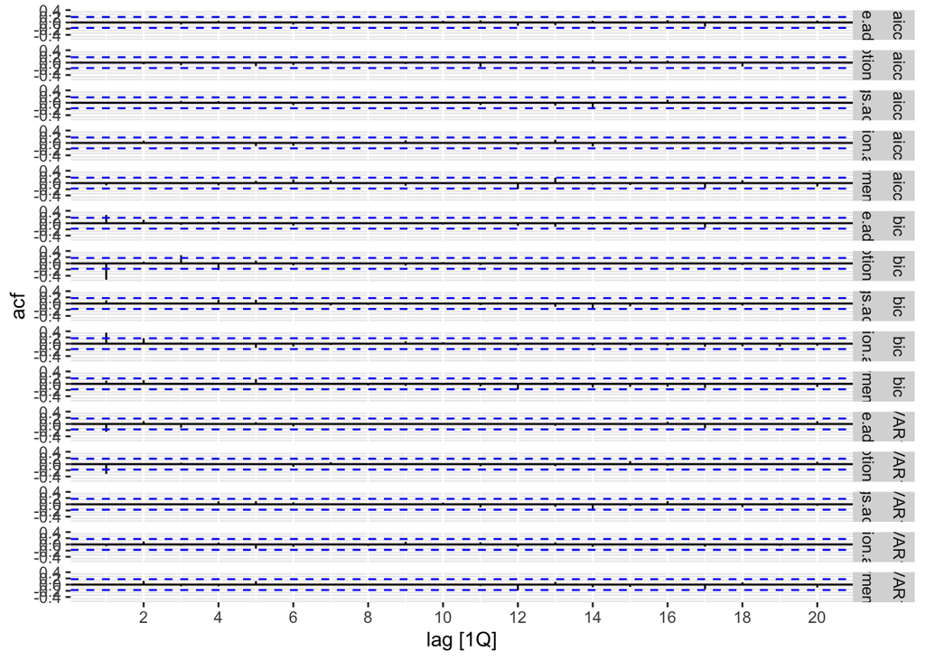

```r
fit %>%
  augment() %>%
  ACF(.innov) %>%
  autoplot()
```

Residuals are better for AICc but BIC model is simpler

## Forecasting

Let’s forecast 2 years ahead

Consider first, in the testing set, the actual values instead of the adjusted ones

```r
n_rows <- nrow(dataUS)
dataUS[(n_rows-7):n_rows, 7:11] <- dataUS[(n_rows-7):n_rows, 2:6]
```

Accuracy:

```r
fit%>%
  forecast(h=8)  %>% accuracy(dataUS)
```

```
## # A tibble: 15 × 11
##    .model .response     .type       ME    RMSE     MAE     MPE  MAPE  MASE RMSSE
##    <chr>  <chr>         <chr>    <dbl>   <dbl>   <dbl>   <dbl> <dbl> <dbl> <dbl>
##  1 VAR1   Consumption.… Test   1.09e-2 0.0116  0.0109    69.7   69.7 1.27  0.828
##  2 VAR1   Income.adjus… Test   5.53e-3 0.00797 0.00769   36.5   73.0 0.967 0.695
##  3 VAR1   Production.a… Test   2.52e-4 0.00754 0.00576   12.5  111.  0.431 0.367
##  4 VAR1   Savings.adju… Test  -1.06e-1 0.314   0.255    102.   102.  1.61  1.42
##  5 VAR1   Unemployment… Test  -1.24e-2 0.0576  0.0498    68.1  103.  1.14  1.05
##  6 aicc   Consumption.… Test  -1.27e-3 0.00896 0.00692  -22.0   46.6 0.810 0.638
##  7 aicc   Income.adjus… Test  -4.52e-3 0.00692 0.00481  -58.5   60.8 0.604 0.603
##  8 aicc   Production.a… Test  -1.32e-2 0.0156  0.0132  -403.   535.  0.990 0.758
##  9 aicc   Savings.adju… Test  -6.58e-2 0.373   0.293     83.2  108.  1.85  1.69
## 10 aicc   Unemployment… Test   1.08e-2 0.0489  0.0386  -286.   407.  0.881 0.888
## 11 bic    Consumption.… Test   1.52e-3 0.00520 0.00412   -1.65  28.9 0.483 0.370
## 12 bic    Income.adjus… Test  -2.09e-5 0.00333 0.00263  -10.1   26.4 0.331 0.290
## 13 bic    Production.a… Test  -4.40e-3 0.00894 0.00703 -199.   307.  0.525 0.435
## 14 bic    Savings.adju… Test  -7.69e-2 0.286   0.238     97.3   97.3 1.50  1.29
## 15 bic    Unemployment… Test  -1.54e-2 0.0618  0.0523    79.7   95.6 1.19  1.12
## # ℹ 1 more variable: ACF1 <dbl>
```

Forecasting plot for the next 2 years:

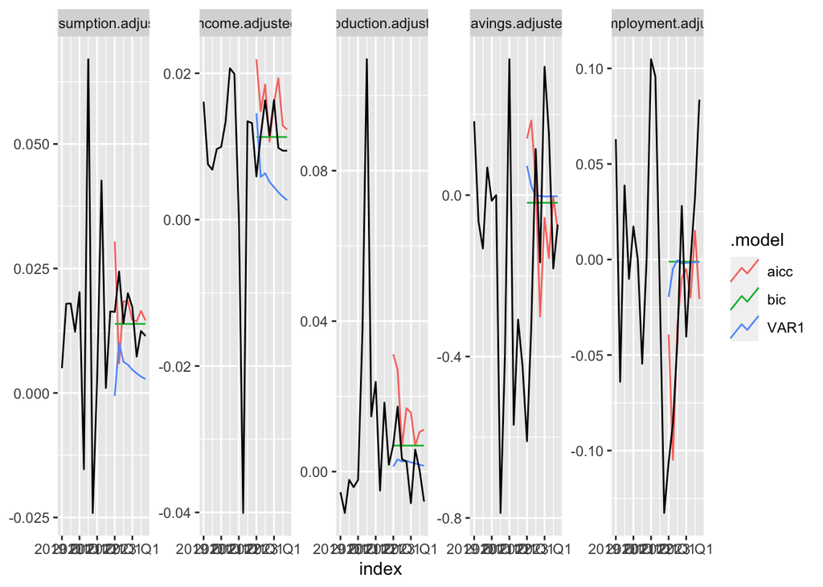

```r
fit%>%
  forecast(h=8) %>%
  autoplot(dataUS %>% filter(year(index) >= 2019), level = NULL)
```

Insights?

# VAR models in high dimension

Let’s use the **bigtime** library to sparsely estimate large multivariate time-series models This library estimates big VARMA models using an L1-penalty (lasso penalty)

Estimation:

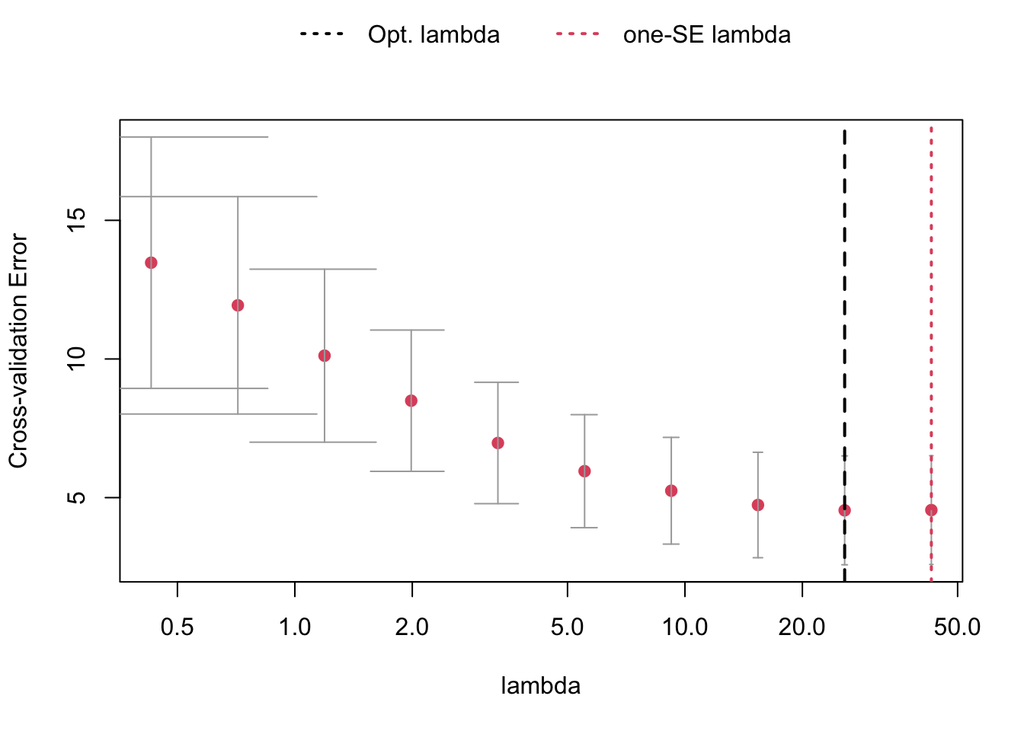

```r
library(bigtime)

VAR.L1 <- sparseVAR(Y=scale(as.matrix(head(dataUS[,-c(1:6)],-8))), # leave 2022 and 2023 for testing
                    h = 1, # evaluate forecasts 1 quarter ahead
                    selection = "cv", # using time series cross-validation
                    VARpen = "L1") # using the lasso penalty)

plot_cv(VAR.L1)
```

As with glmnet, this library plots the mean forecasting error for each penalization together with error bars for plus-minus one standard deviation.

The black dashed line indicates the penalty parameter choice that lead to the smallest MSFE in the CV procedure: better for forecasting. The red dotted line, on the other hand, shows the one-standard-error solution: better for interpretation.

Let’s see the lag matrix between predictors and responses

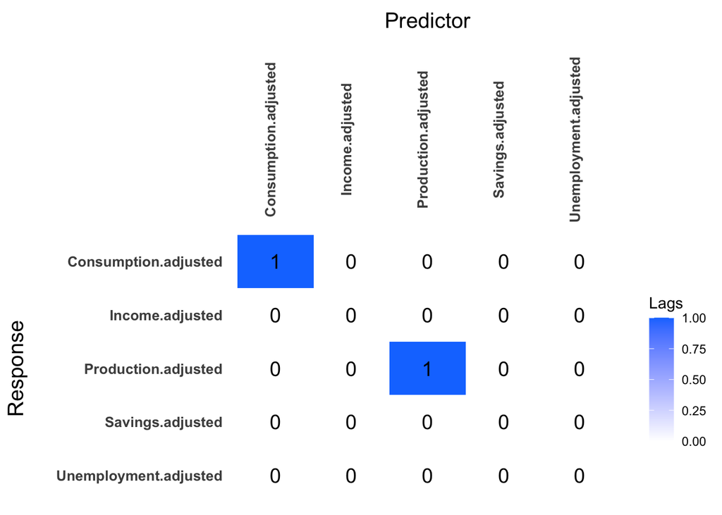

```r
LhatL1 <- lagmatrix(fit=VAR.L1, returnplot=TRUE)
```

## Forecasting

They can be direct for just one period (that must be the same h as in the estimation), or recursive (for many periods up to the horizon)

```r
# 1-quarter ahead direct forecasts
directforecast(VAR.L1, h=1)
```

```
## [1] -0.0183585934 -0.0367185529 -0.0003913914 -0.0047290929 -0.0067412223
```

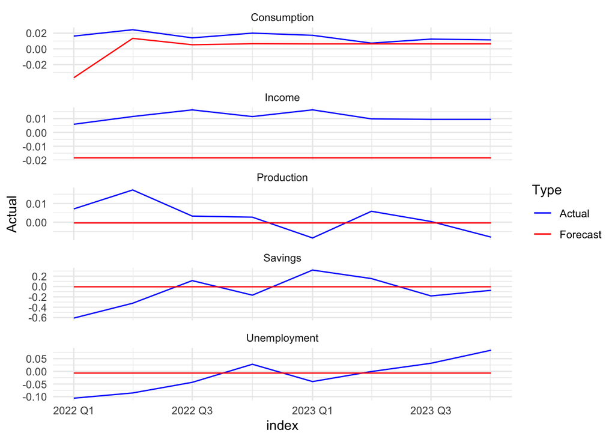

```r
# 2-year ahead recursive forecasts
forecast_data = as.data.frame(recursiveforecast(VAR.L1, h=8)$fcst)
forecast_data = forecast_data %>% mutate(index = tail(dataUS$index,8))

# real values for 2022 and 2024
actual_data = tail(dataUS[,1:6],8)

# Combine the actual and forecast data into long format for plotting
actual_long <- pivot_longer(actual_data, -index, names_to = "Variable", values_to = "Actual")
forecast_long <- pivot_longer(forecast_data, -index, names_to = "Variable", values_to = "Forecast")
forecast_long$Variable <- sub(".adjusted", "", forecast_long$Variable) # Remove '.adjusted' for matching

# Merge actual and forecast data
combined_data <- merge(actual_long, forecast_long, by = c("index", "Variable"))

# Plotting
ggplot(combined_data, aes(x = index)) +
  geom_line(aes(y = Actual, colour = "Actual")) +
  geom_line(aes(y = Forecast, colour = "Forecast")) +
  facet_wrap(~ Variable, scales = "free_y", nrow = 5) +
  theme_minimal() +
  labs(colour = "Type") +
  scale_colour_manual(values = c("Actual" = "blue", "Forecast" = "red"))
```